## Amazon analysis for COM5508 by Ian Zhang

After practising the codes in class, I figured out several questions which could be solved by plain python codes.One of my questions is

> "there is a positive relationship between the food price, and review scores for the food.If one kind of food is more expensive then comparatively this one could get higher score."

I wrote my codes as below.

#### Load json files which teacher adjested in last course

```python
from matplotlib import pyplot as plt
import json
products = json.load(open('gourmet_products.json'))
reviews = json.load(open('gourmet_reviews.json'))
```

#### Create a list_id which collects all asin codes

```python
t = set()
for item in reviews:
    t.add(item['asin']) # make a asin code set as asin code may repeat in reviews.
list_id = list(t) #transfer this set into a list
```

#### Screening those products which do not have the key:"price"

```python
list_id_no_price = [] #there are some items in products which don't have the price.
dict_price = {}
for id in list_id:
    if('price' in products[id].keys()):
        dict_price[id] = products[id]['price']
    else:
        list_id_no_price.append(id)
        continue
list_id = list(set(list_id).difference(set(list_id_no_price)))
```

#### Create a price_list from screened list_id

```python
price_list = []
for key in dict_price:
    price_list.append(dict_price[key])
print((price_list[0:5]))
```

```
[37.45, 16.35, 31.39, 29.99, 51.01]
```

#### Create a dict, the asin code is the key and all reviews are the values

```python
p_reviews = {}
for review in reviews:
    asin = review['asin']
    if asin not in p_reviews:
        p_reviews[asin] = [review]
    else:
        p_reviews[asin].append(review)
```

#### Create 2 lists, one collects the total scores for one product,another collects the number of reviews for one product.

```python
list_single_item = []
list_single_total = []
list_everyitem_length = []
su = 0

#create a list which collects the total scores for each product
for i in list_id:
    list_single_total.append(su)
    list_single_item = []
    for j in range(len(p_reviews[i])):
        length = len(p_reviews[i])
        list_single_item.append(p_reviews[i][j]['overall'])
        su = sum(list_single_item)

#crate a list which collects the number of reviews for each product
for i in list_id:
    list_everyitem_length.append(len(p_reviews[i]))
```

#### Dividing items in both list to get the average score as a result

```python
#adjest this list
last_value = list_single_total[0]
list_single_total.pop(0)
list_single_total.append(last_value)

f = lambda x,y : x / y
results = map(f,list_single_total,list_everyitem_length)
results = list(results)
print(results[0:5])
```

```
[4.375, 4.25, 5.0, 2.8, 4.875]
```

#### plotting

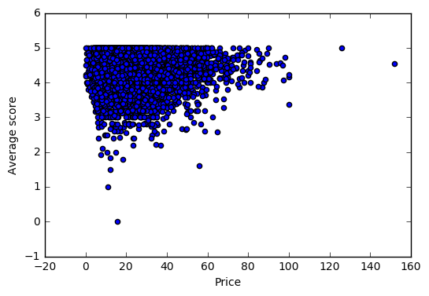

```python
plt.scatter(price_list,results)
plt.xlabel("Price")
plt.ylabel("Average score")
plt.show()
```